# stec3

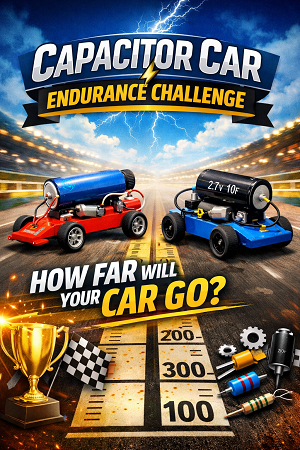

## Desafío de distancia de autitos a capacitor (Capacitor Car Endurance Challenge)

La idea base es hacer un autito de un cuerpo de aluminio (o madera) con un motor eléctrico que se alimenta con la descarga de un capacitor. La idea es lograr combinar la mecánica (precisión y calidad de la construcción) junto con un circuito de descarga del capacitor conveniente (calcular, elegir, ir tanteando la resistencia) que permita que el autito ande el mayor tiempo (distancia) posible. La resistencia debería poder sacarse del circuito con facilidad para cambiar por otra y probar. El capacitor podría ser comprado, para todos el mismo, o que se construya a mano. Se puede armar una competencia y ser entretenido. Creo que tiene suficientes partes de electrónica, mecánica y dibujo para hacer algo inegrador.

### Sobre la mecánica

Pienso que se puede usar como base una barra redonda o hexagonal de aluminio que ya hay en el colegio. Otro esquema sería con hojalata de aluminio sacada da las latas de coca. Dependiendo de lo que se quiera puede involucrar el uso de varias herramientas e incluso algún torneado sencillo que es lo que se viene ya haciendo estos años. Si aun así resulta pesado se puede usar madera o diversas combinaciones.

Se busca un vehículo liviano y de baja fricción. La transmisión puede ser simple, por ejemplo motor–rueda con banda elástica y poleas, con una relación cercana a 1:1 como punto de partida. Conviene usar ruedas relativamente grandes (sin exagerar) para mejorar el desplazamiento. Algunos parámetros pueden fijarse (tipo de motor, capacitor, materiales básicos) y otros dejarse a elección (peso, diámetro de ruedas, relación de transmisión) para que los alumnos experimenten y optimicen la distancia recorrida.

### Sobre la eléctrónica

(Este campo no es de mi dominio pero me orienté por IA)

Los componentes para un circuito simple son:

- capacitor electrolítico grande (2200–4700 µF o más)
- resistencia de carga (tendría que tener un montaje que permita intercambiarla)
- diodo de protección del motor
- botón de arranque

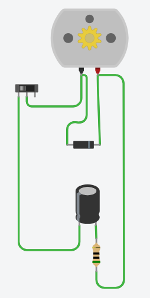

El circuito de carga consiste en un cargador de celular con una resistencia en serie que se conecta al capacitor durante unos segundos. Este sistema es externo al vehículo, es decir, no forma parte del autito.

Esto ya permite trabajar varios conceptos: tiempo de carga y descarga (RC), energía almacenada en el capacitor, influencia de la resistencia en el comportamiento del motor, y la función de protección del diodo.

Como posible mejora o extensión, puede incorporarse un circuito de retardo con transistor, que permita un arranque automático del vehículo luego de la carga. Otra función de esto es evitar pulsar un interruptor manualmente y evitar la suspicacia de que alguien impulse el autito en ese movimiento.

Incluso, si vale la pena el aporte, se puede hacer que fabriquen el capacitor.

### Cuestiones interesantes

Por más que haya un diseño base la determinación de la resistencia correcta termina siendo una cuestión de probar, medir y optimizar casi para cada autito en particular:

- Resistencia baja → mucha corriente → acelera fuerte pero se descarga rápido.
- Resistencia alta → poca corriente → dura más tiempo pero puede no moverse.

Hay que encontrar un equilibrio entre el par del motor y la duración de la descarga para que el auto vaya lo más lejos posible.

### Fuentes de inspiración

- Super capacitor dragster de Tom Stanton [Link](https://www.youtube.com/watch?v=xmrSv76yhio)

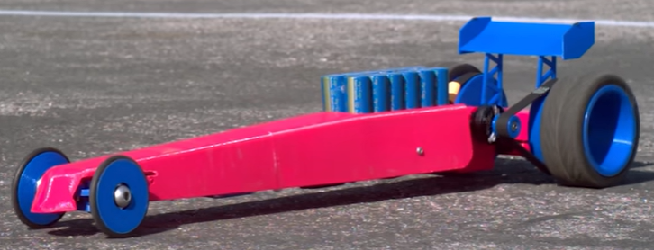

- Modelo de autito a capacitor en Instructables [Link](https://www.instructables.com/The-Capacitor-Powered-Car/)

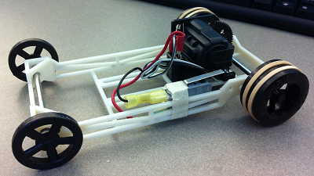

- Triciclo con motor y capacitor. Distintos ensayos. [Link](https://www.youtube.com/watch?v=HUVeBJvp78c)
- Carrera de distancia de autos a capacitor promocionada por Universidad de Ontario [Link](https://engineering.ontariotechu.ca/current-students/current-undergraduate/innovation-and-design-studio/engineering-demo-fest-project-capacitor-powered-vehicle-race.pdf)
- Otras fuentes secundarias especializadas:
  - Capacitor Powered Vehicle Project [Link](https://electronics.stackexchange.com/questions/199980/capacitor-powered-vehicle-project)
  - Ultra-Capacitor Powered Car [link](https://www.eevblog.com/forum/beginners/ultra-capacitor-powered-car/)

[figure not shown]